# Exercise: Handling Missing Data

Marga Torre

2024-02-20

## Read data

Load “extracted_data_wrangling_code.R” to clean up variables

Filter data for Round 9

```r
data<- data |> filter(data$essround==9)
```

Select the following variables: identification number, age, sex, years of schooling, and household income

```r
data<-data |> select("idno", "hincome", "male", "age", "years_schooling")
```

To handle categorical variables (e.g. male), we encode the levels and recode the values to end up with a numeric variable ranging from 0 to 1.

```r
data <- data |>
  mutate_if(is.factor, as.numeric) |>
    mutate(male = recode(male, `2` = 0))
str(data)
```

```
## tibble [1,668 × 5] (S3: tbl_df/tbl/data.frame)
##  $ idno           : num [1:1668] 27 76 182 234 246 254 382 395 419 438 ...
##  $ hincome        : num [1:1668] NA 1 9 2 NA NA 5 2 NA 8 ...
##  $ male           : num [1:1668] 0 0 0 1 1 1 0 0 1 1 ...
##  $ age            : num [1:1668] 65 65 42 40 71 90 35 68 53 31 ...
##  $ years_schooling: num [1:1668] 13 10 19 13 8 NA 8 6 12 18 ...
```

Let’s run a linear regression to estimate the years of schooling based on household income, age, and gender of the interviewee.

```r
m0<-lm(years_schooling ~ age + male + hincome, data)
summary(m0)
```

```
##
## Call:
## lm(formula = years_schooling ~ age + male + hincome, data = data)
##
## Residuals:
##     Min      1Q  Median      3Q     Max
## -14.283  -3.534  -0.764   2.650  46.611
##
## Coefficients:
##              Estimate Std. Error t value Pr(>|t|)
## (Intercept) 14.229318   0.711327  20.004   <2e-16 ***
## age         -0.102085   0.009984 -10.225   <2e-16 ***
## male         0.591258   0.352220   1.679   0.0935 .
## hincome      0.728911   0.070497  10.340   <2e-16 ***
## ---
## Signif. codes:  0 '***' 0.001 '**' 0.01 '*' 0.05 '.' 0.1 ' ' 1
##
## Residual standard error: 5.975 on 1180 degrees of freedom
##   (484 observations deleted due to missingness)
## Multiple R-squared:  0.1787, Adjusted R-squared:  0.1766
## F-statistic:  85.6 on 3 and 1180 DF,  p-value: < 2.2e-16
```

As observed, 484 observations have been excluded due to missing data. First, let’s examine the amount of missing data within each covariate.

```r
# Using is.na()
summary(is.na(data))
```

```
##     idno          hincome           male            age
##  Mode :logical   Mode :logical   Mode :logical   Mode :logical
##  FALSE:1668      FALSE:1205      FALSE:1668      FALSE:1667
##                  TRUE :463                       TRUE :1
##  years_schooling
##  Mode :logical
##  FALSE:1614
##  TRUE :54
```

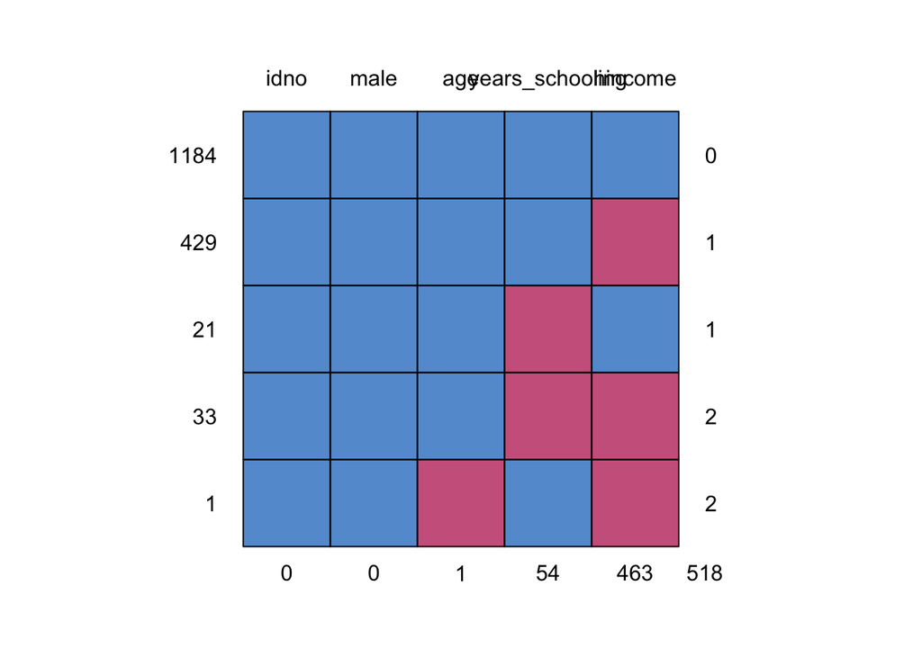

```
##      idno male age years_schooling hincome
## 1184    1    1   1               1       1   0
## 429     1    1   1               1       0   1
## 21      1    1   1               0       1   1
## 33      1    1   1               0       0   2
## 1       1    1   0               1       0   2
##         0    0   1              54     463 518
```

```r
# Using md.pattern() from `mice`
md.pattern(data)
```

There are three variables with missing data: ‘household income’ (463 cases), ‘age’ (1 case), and ‘years of schooling’ (54 cases), with the latter being the outcome variable. Begin the imputation of missing data by using the median, and then apply the mice() function with methods *norm.boot*, *pmm*, and *rf*. In all cases, generate 10 imputed datasets

```r
library(mice)
data_imputed <- data.frame(
  idno = data$idno,
  original = data$hincome,
  imputed_median = replace(data$hincome, is.na(data$hincome), median(data$hincome, na.rm = TRUE)),
  imputed_normboot = complete(mice(data, m=10, method = "norm.boot", seed=123))$hincome,
  imputed_pmm = complete(mice(data, m=10, method = "pmm", seed=123))$hincome,
  imputed_rf = complete(mice(data, m=10, method = "rf", seed=123))$hincome
)
```

```r
head(data_imputed, 10)
```

|  | idno | original | imputed_median | imputed_normboot | imputed_pmm | imputed_rf |
| --- | --- | --- | --- | --- | --- | --- |
| 1 | 27 | NA | 5 | 2.332257 | 1 | 7 |
| 2 | 76 | 1 | 1 | 1.000000 | 1 | 1 |
| 3 | 182 | 9 | 9 | 9.000000 | 9 | 9 |
| 4 | 234 | 2 | 2 | 2.000000 | 2 | 2 |
| 5 | 246 | NA | 5 | 5.362934 | 5 | 3 |
| 6 | 254 | NA | 5 | 6.855309 | 2 | 5 |
| 7 | 382 | 5 | 5 | 5.000000 | 5 | 5 |
| 8 | 395 | 2 | 2 | 2.000000 | 2 | 2 |
| 9 | 419 | NA | 5 | 4.980418 | 5 | 2 |
| 10 | 438 | 8 | 8 | 8.000000 | 8 | 8 |

Plot the results to compare the resulting distributions

[figure not shown]

```r
# Define variables, titles, and colors for the new imputation methods
variables <- c("original", "imputed_median", "imputed_normboot", "imputed_pmm", "imputed_rf")
titles <- c("Distribution of the Age Variable", "Median-imputed Distribution", "Norm Boot-imputed Distribution", "PMM-imputed Distribution", "Random Forest-imputed Distribution")
colors <- c("skyblue", "orchid", "aquamarine", "coral", "hotpink")

# Initialize an empty plot list for the new plots
plots <- list()

# Loop through variables to create plots for each imputation method
for (i in 1:length(variables)) {
  plots[[i]] <- ggplot(data_imputed, aes_string(x = variables[i])) +
    geom_histogram(binwidth = 1, fill = colors[i], color = paste0(colors[i], "3")) +
    ggtitle(titles[i]) +
    theme_classic()
}

# Combine plots into a grid, adjusting for the total number of plots
plot_grid(plotlist = plots, nrow = 3, ncol = 2)
```

```r
data <- data |>
  left_join(data_imputed, by = "idno") |>
  select(idno, years_schooling, age, male, hincome, imputed_rf)

head(data, 6)
```

| idno | years_schooling | age | male | hincome | imputed_rf |
| --- | --- | --- | --- | --- | --- |
| 27 | 13 | 65 | 0 | NA | 7 |
| 76 | 10 | 65 | 0 | 1 | 1 |
| 182 | 19 | 42 | 0 | 9 | 9 |
| 234 | 13 | 40 | 1 | 2 | 2 |
| 246 | 8 | 71 | 1 | NA | 3 |
| 254 | NA | 90 | 1 | NA | 5 |

What happens is that if you perform a merge, it only imports data from the first imputed dataset, ignoring the other 9 imputed dataset. Therefore, the best course of action is to recalculate the imputations to inspect them and ensure everything is correct before pooling.

Prepare data for Multiple Imputation:

```r
data<-data |> select("hincome", "male", "age", "years_schooling")
init = mice(data)
meth = init$method
```

Specify a vector of variables that won’t be imputed but will be used for prediction

```r
meth[c("years_schooling")]=""
```

Specify the method for imputing the missing values

```r
meth[c("hincome", "age")]="rf"
```

```r
imputed_rf = mice(data, method=meth, m=10, seed=123)
summary(imputed_rf)
```

```
## Class: mids
## Number of multiple imputations:  10
## Imputation methods:
##         hincome            male             age years_schooling
##            "rf"              ""            "rf"              ""
## PredictorMatrix:
##                 hincome male age years_schooling
## hincome               0    1   1               1
## male                  1    0   1               1
## age                   1    1   0               1
## years_schooling       1    1   1               0
```

Finally, run a linear regression using the imputed values from the `rf` method. As observed, there are now only 54 missing values, all corresponding to the dependent variable.

```r
m1 <- with(imputed_rf, glm(years_schooling ~ age + male + hincome))
summary(pool(m1))
```

| term | estimate | std.error | statistic | df | p.value |
| --- | --- | --- | --- | --- | --- |
| (Intercept) | 14.3454952 | 0.625078200 | 22.94992 | 235.04441 | 6.046109e-62 |
| age | -0.0932506 | 0.008109637 | -11.49874 | 1191.43249 | 4.302258e-29 |
| male | 0.4322192 | 0.297019177 | 1.45519 | 1533.55805 | 1.458215e-01 |
| hincome | 0.6099026 | 0.072320406 | 8.43334 | 74.23471 | 1.917920e-12 |

Interpret the results.